# Etude de Cas

- Thèmes abordès : Modern Portfolio theory - Optimisation sous-contraintes - Matrice de Corrlation bruitée
- Papier étudié : Noise Dressing of Financial Correlation Matrices https://journals.aps.org/prl/abstract/10.1103/PhysRevLett.83.1467

## Le Cas à étudier

Un investisseur souhaite minimizer le risque de son portfeuille sous certaines contrainres du rendement espéré.

## Parie 1 : Modélisation Mathémathiques

$ N $ : Nombre d'actifs dans le portfeuille.  
$ w^T = (w_1, ..., w_N) $ : Un vecteur où $w_i$ et la quatité investie dans l'actif i du portfeuille où $i \in \{1, ..., N\}$.  
$ R^T = (R_1, ..., R_N) $ : Un vecteur **aléatoire** réelle où $R_i$ est le rendement de l'actif i.  
$ \Sigma = (\sigma_{ij})_{1 \leq i,j \leq N} $ : La matrice variance-covariance de vecteur R.  
$R_p = w^T R$ : Rendement du portfeuille.  
$\mu^T = (E[R_1], ..., E[R_N])$ Vecteur des rendments moyens.  
$\mu_p = w^T\mu$ : Rendement espéré du portefeuille.  
$ w^T\Sigma w = Var[R_p] $ : Variance du rendenet du portefeuille.  
$\overline{R}$ : Rendement espéré.

### Solution

On se ramène à un problème d'optimisation sous contraintes :

\begin{matrix} \min_w \frac{1}{2}w^T\Sigma w\\ \text{s.c } w^T\mu = \overline{R} \end{matrix}

Dont le largragien :

$ \min_w \frac{1}{2}w^T\Sigma w - \lambda( w^T\mu -\overline{R}) $

Notre problème est convexe. Donc, la condidtion du premier ordre nous donne la solution : $ \frac{\partial }{\partial w} \left( \frac{1}{2} w^T\Sigma w - \lambda( w^T\mu -\overline{R}) \right) = 0, $ $ \frac{\partial }{\partial w} \left( \frac{1}{2} w^T\Sigma w \right) - \lambda \frac{\partial }{\partial w} ( w^T\mu) = 0, $

$ \Sigma w - \lambda \mu = 0 $

$ \Rightarrow w= \lambda \Sigma^{-1} \mu = \lambda \mu^T\Sigma^{-1} \text{ , car } \Sigma \text{ et son inverse sont symétrique} $

Or, $\Sigma$ est une matrice de symétrique donc diagonisable dans une base orthonormale selon la théorème spectrale. En plus, elle est définie positive donc ses valeurs propores sont des réelles strictement positives. Donc : $ \Sigma = QDQ^{-1} = QDQ^T $ Avec  
$Q = [v_1 v_2 ... v_N] $ La matrice de vecteurs propres (orthogonale)  
$D = diag((\sigma^v_1)^2, ..., (\sigma^v_N)^2) $ : Matrice diagonale des valeurs propres (strictement positive )  
Dans ce cas :

$ \Sigma^{-1} = (QDQ^T)^{-1} = QD^{-1}Q^T $ et la solution devient : $ w = \lambda QD^{-1}Q^T \mu $ $ w = \lambda QD^{-1}[v_1^T\mu, ..., v_n^T\mu]^T $

$ w = \lambda [v_1 v_2 ... v_N] [ \frac{v_1^T\mu}{(\sigma^v_1)^2}, ..., \frac{v_n^T\mu}{(\sigma^v_n)^2}]^T $

$ \boxed{w = \lambda \sum_{i=1}^N \frac{v_i^T\mu}{(\sigma^v_i)^2}v_i} $

Finalement, la quantité investie dans l'actif $j \in \{1, ..., N\} $ est égale à $ \boxed{w_j = \lambda \sum_{i=1}^N\frac{v_i^T\mu}{(\sigma^v_i)^2}v_{i,j}}$

On remarque que les petits valeurs propres vont amplifier le choix de certains actifs cependant elle se sont les valeurs les plus sensibles au bruit et ne correspondront pas forcement au choix le moins risqué.

En fin, pour calculer le lagragien, il suffit d'injecter la solution dans notre contrainte et on obtinet :

$ w^T\mu = \lambda \sum_{i=1}^N \left(\frac{v_i^T\mu}{\sigma^v_i}\right)^2 = \overline{R} \Rightarrow \boxed{\lambda = \frac{\overline{R}}{\sum_{i=1}^N \left(\frac{v_i^T\mu}{\sigma^v_i}\right)^2}} $

## Partie 2 : Analyse numérique et statistique

Arpès avoir vu l'importance de la matrice de correlation (matrice de variance-covariance) dans la construction d'un portfeuille selon la théorie moderne de Markowitch, nous nous interssons à étudier l'effet du *bruit* et de la *taille* de l'échantillon (l'horizon du temps des séries temporelles) sur la determination de la **matrice de correlation empirique** (car en réalité nous ne nous connaissons la vraie matrice de correlation).  
Cette étude a été mené dans le papier 'Noise Dressing of Finacial Correlation Matrices'. (*Nous validons les résultats obtenus numériquement*). Ce papier a également proposé une manière pour gérer le bruit dans les plus petits valeurs propres.

```python
import numpy as np
from numpy import linalg as LA
import matplotlib.pyplot as plt
from scipy.stats import gaussian_kde
np.random.seed(5)
```

### Simulation d'un marché

```python
T = 100 # Horizon du temps = taille de l'échantillon pour les calculs empiriques
N = 5 # Nombre des actifs
Mu = np.linspace(-0.0005,0.0005,N)
Std = (1+Mu*100)/3

# Simunlation de la portfeuille
# R la matrice de rendement où R[i][t] le rendement de l'actif i à l'instat
R = np.zeros((N,T))
for i in range(N):
    R[i] = np.random.normal(Mu[i], Std[i],T)
```

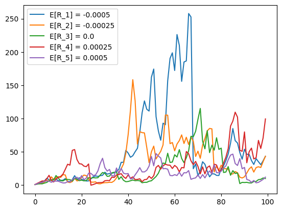

```python
v = np.ones((N,T))
for i in range(N):
    for t in range(1,T):
        v[i][t] =max(0.001,v[i][t] + (1+R[i][t])*v[i][t-1])

    plt.plot(v[i], label='E[R_'+str(i+1)+'] = ' + str(Mu[i]))

plt.legend()
```

### Étdue de la distibution du spectre d'une matrice de correlation aléatoire

On suppose que les redments de tous les actifs sont des variables normales centrées réduites. La matrice de correlation empirique $\Sigma_T$ est donc égale à $ \frac{1}{T} R^{ \text{T}}R $.  
Quand $T \to \infty$, $\Sigma_T \to \Sigma = I $. Cette matrice $\Sigma_T$ suit la loi de Wishart $W_N(T, \frac{1}{T} \Sigma)$. $\Sigma$ est la vrai matrice de variance-convariance qui est égale à l'identité.  
On prend $T = QN$ avec $1 \leq Q$.  
**Les résultats ci dessous correspondent bien aux résultats du papier.**

#### $Q = 3.22$

```python
N = 400 # Nombre des actifs
Q = 3.22
T = int(Q*N) # Horizon du temps = taille de l'échantillon pour les calculs empiriques

# Simunlation de la portfeuille
# R la matrice de rendement où R[i][t] le rendement de l'actif i à l'instat
R = np.zeros((N,T))
for i in range(N):
    R[i] = np.random.normal(0, 1,T)
```

```python
Sigma_T = (1/T)*R.dot(R.T) # matrice de correlation empirique des variable centrées réduites
sigma_v, v_p = LA.eig(Sigma_T) # calculer les valeurs propres et les vecteurs propres
```

**Les valeurs empriques des bornes sont priches des valeurs théoriques.**

```python
lambda_min_T, lambda_max_T = sigma_v.min(), sigma_v.max() # les bornes empiriques des valeurs propes
lambda_min, lambda_max = 1+1/Q -2*(1/Q)**0.5, 1+1/Q +2*(1/Q)**0.5 # les bornes théoriques des valeurs propes
print("Bornes empiriques : ", lambda_min_T, lambda_max_T)
print("Bornes théoriques : ",lambda_min, lambda_max)
```

```
Bornes empiriques :  0.1999016546471712 2.37539690017158
Bornes théoriques :  0.1960025810604744 2.4251154313618857
```

**Les résultats empiriques correspondent aux résultats théoriques pour la distribution des valeurs propres aussi.**

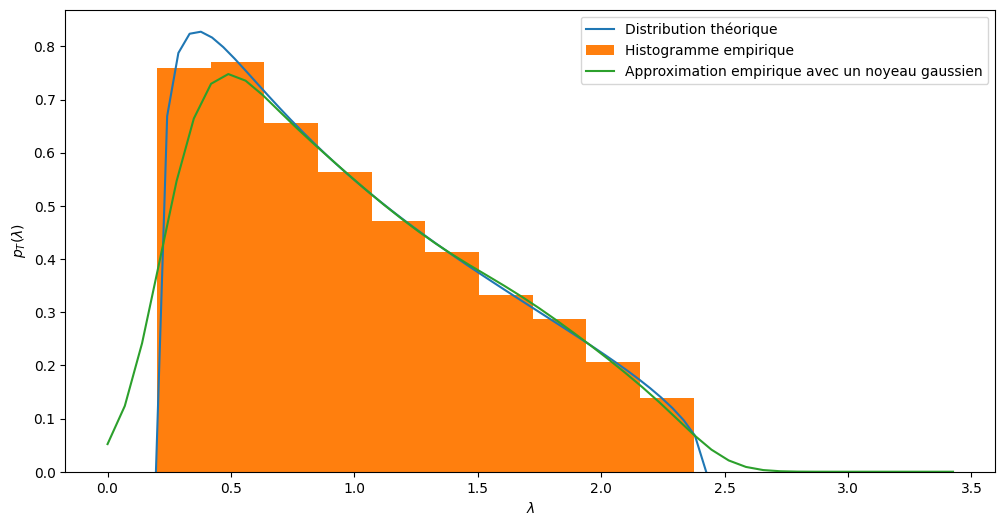

```python
lambda_ = np.linspace(lambda_min,lambda_max )
distribution = [
    Q*(0.5/np.pi)*( (lambda_max-lambda_[i])*(lambda_[i] -lambda_min ) )**0.5/lambda_[i]
    for i in range(50)
]


plt.figure(figsize=(12,6))

plt.plot(lambda_,distribution, label='Distribution théorique' )

plt.hist(sigma_v, density=True,label='Histogramme empirique')



density = gaussian_kde(sigma_v)
xs = np.linspace(0,lambda_max+1)
density.covariance_factor = lambda : .25
density._compute_covariance()

plt.plot(xs,density(xs), label = 'Approximation empirique avec un noyeau gaussien')

plt.xlabel('$\lambda$')

plt.ylabel('$p_T(\lambda)$')
plt.legend()
plt.figure()
plt.show()
```

**C'est aussi le cas pour la distribution des composents des vecteurs proreses**

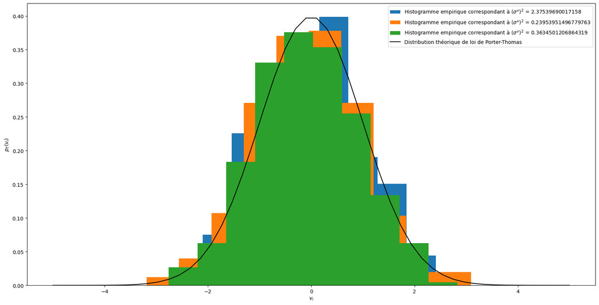

```python
plt.figure(figsize = (20,10))

plt.hist((N)**0.5*v_p[0],density=True, label='Histogramme empirique correspondant à $(\sigma^v)^2$ = ' + str(sigma_v[0]))
plt.hist((N)**0.5*v_p[100],density=True, label='Histogramme empirique correspondant à $(\sigma^v)^2$ = ' + str(sigma_v[100]))
plt.hist((N)**0.5*v_p[200],density=True, label='Histogramme empirique correspondant à $(\sigma^v)^2$ = ' + str(sigma_v[200]))
u = np.linspace(-5,5)
plt.plot(u, (2*np.pi)**(-0.5)*np.exp(-u**2/2), label = 'Distribution théorique de loi de Porter-Thomas', color = 'black')

plt.xlabel('$v_i$')

plt.ylabel('$p_T(v_i)$')
plt.legend()
plt.show()
```

#### $Q = 200 (T \gg N)$

On remarque la loi de distribution des valauers propre converge vers une distribution de dirac $δ_1$ ce qui correspond bien avec les résultats théoriques souhaités. Et les bornes commence à converger vers 1 quand $T→∞$ , $λ^T_{min}↗1$ et $λ^T_{max}↘1$

```
Bornes empiriques :  0.8649597282814177 1.1465817954917743
Bornes théoriques :  0.8635786437626904 1.1464213562373093
```

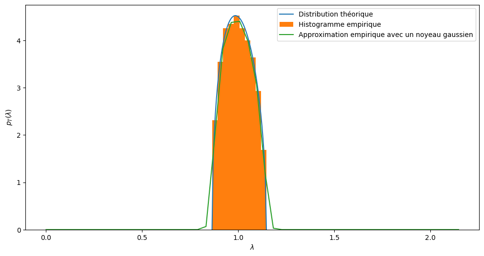

```python
N = 400 # Nombre des actifs
Q = 200
T = int(Q*N) # Horizon du temps = taille de l'échantillon pour les calculs empiriques

# Simunlation de la portfeuille
# R la matrice de rendement où R[i][t] le rendement de l'actif i à l'instat
R = np.zeros((N,T))
for i in range(N):
    R[i] = np.random.normal(0, 1,T)



Sigma_T = (1/T)*R.dot(R.T) # matrice de correlation empirique des variable centrées réduites
sigma_v, v_p = LA.eig(Sigma_T) # calculer les valeurs propres et les vecteurs propres


lambda_min_T, lambda_max_T = sigma_v.min(), sigma_v.max() # les bornes empiriques des valeurs propes
lambda_min, lambda_max = 1+1/Q -2*(1/Q)**0.5, 1+1/Q +2*(1/Q)**0.5 # les bornes théoriques des valeurs propes
print("Bornes empiriques : ", lambda_min_T, lambda_max_T)
print("Bornes théoriques : ",lambda_min, lambda_max)




lambda_ = np.linspace(lambda_min,lambda_max )
distribution = [
    Q*(0.5/np.pi)*( (lambda_max-lambda_[i])*(lambda_[i] -lambda_min ) )**0.5/lambda_[i]
    for i in range(50)
]


plt.figure(figsize=(12,6))

plt.plot(lambda_,distribution, label='Distribution théorique' )

plt.hist(sigma_v, density=True,label='Histogramme empirique')



density = gaussian_kde(sigma_v)
xs = np.linspace(0,lambda_max+1)
density.covariance_factor = lambda : .25
density._compute_covariance()

plt.plot(xs,density(xs), label = 'Approximation empirique avec un noyeau gaussien')

plt.xlabel('$\lambda$')

plt.ylabel('$p_T(\lambda)$')
plt.legend()
plt.figure()
plt.show()
```

#### Q = 1

On remarque la divergence de la distribution des valeurs propres au voisinage du 0.

```
Bornes empiriques :  9.678330299271933e-07 3.9487361251025694
Bornes théoriques :  0.0 4.0
```

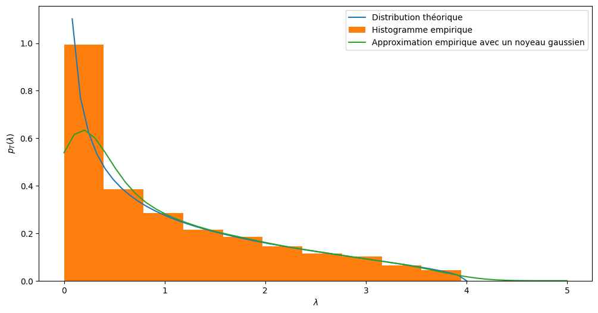

```python
N = 400 # Nombre des actifs
Q = 1
T = int(Q*N) # Horizon du temps = taille de l'échantillon pour les calculs empiriques

# Simunlation de la portfeuille
# R la matrice de rendement où R[i][t] le rendement de l'actif i à l'instat
R = np.zeros((N,T))
for i in range(N):
    R[i] = np.random.normal(0, 1,T)



Sigma_T = (1/T)*R.dot(R.T) # matrice de correlation empirique des variable centrées réduites
sigma_v, v_p = LA.eig(Sigma_T) # calculer les valeurs propres et les vecteurs propres


lambda_min_T, lambda_max_T = sigma_v.min(), sigma_v.max() # les bornes empiriques des valeurs propes
lambda_min, lambda_max = 1+1/Q -2*(1/Q)**0.5, 1+1/Q +2*(1/Q)**0.5 # les bornes théoriques des valeurs propes
print("Bornes empiriques : ", lambda_min_T, lambda_max_T)
print("Bornes théoriques : ",lambda_min, lambda_max)




lambda_ = np.linspace(lambda_min,lambda_max )
distribution = [
    Q*(0.5/np.pi)*( (lambda_max-lambda_[i])*(lambda_[i] -lambda_min ) )**0.5/lambda_[i]
    for i in range(50)
]


plt.figure(figsize=(12,6))

plt.plot(lambda_,distribution, label='Distribution théorique' )

plt.hist(sigma_v, density=True,label='Histogramme empirique')



density = gaussian_kde(sigma_v)
xs = np.linspace(0,lambda_max+1)
density.covariance_factor = lambda : .25
density._compute_covariance()

plt.plot(xs,density(xs), label = 'Approximation empirique avec un noyeau gaussien')

plt.xlabel('$\lambda$')

plt.ylabel('$p_T(\lambda)$')
plt.legend()
plt.figure()
plt.show()
```

### Gérer le bruit dans les petits valeurs propres

Le papier propose de remplacer les valeurs propres les plus petits qu'un certain seuil par une valeure constante tel que la somme des valaurs propres reste invatriante.